# Proyección del Tipo de Cambio Digital en Bolivia

Modelo ARIMA — Metodología de Box-Jenkins

Análisis Econométrico

17 de julio de 2026

# 1 Comportamiento de la Variable

TC digital: media móvil diaria agregada a frecuencia mensual, desde **noviembre 2023** (primer mes calendario completo con cotización real; oct-2023 se excluye por estar incompleto: 13/31 días) hasta **junio 2026** (32 observaciones).

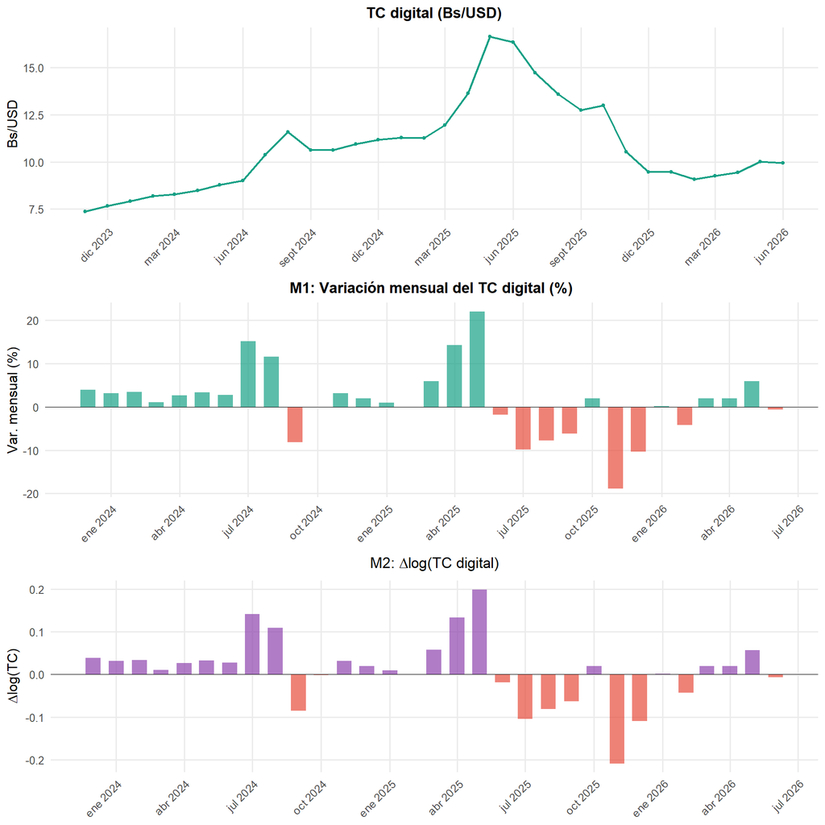

## 1.1 Base de datos consolidada

Base mensual consolidada — TC digital

| Fecha | TC digital | log(TC) | Var. mens.(%) | Var. ia.(%) | Días con dato |
| --- | --- | --- | --- | --- | --- |
| nov 2023 | 7.3693 | 1.9973 | NA | NA | 30 |
| dic 2023 | 7.6635 | 2.0365 | 3.992 | NA | 31 |
| ene 2024 | 7.9084 | 2.0679 | 3.195 | NA | 31 |
| feb 2024 | 8.1803 | 2.1017 | 3.439 | NA | 29 |
| mar 2024 | 8.2697 | 2.1126 | 1.092 | NA | 31 |
| abr 2024 | 8.4893 | 2.1388 | 2.656 | NA | 30 |
| may 2024 | 8.7713 | 2.1715 | 3.321 | NA | 31 |
| jun 2024 | 9.0137 | 2.1987 | 2.763 | NA | 30 |
| jul 2024 | 10.3787 | 2.3398 | 15.144 | NA | 31 |
| ago 2024 | 11.5787 | 2.4492 | 11.562 | NA | 31 |
| sept 2024 | 10.6363 | 2.3643 | -8.139 | NA | 30 |
| oct 2024 | 10.6196 | 2.3627 | -0.157 | NA | 28 |
| nov 2024 | 10.9567 | 2.3939 | 3.174 | 48.68 | 30 |
| dic 2024 | 11.1715 | 2.4134 | 1.961 | 45.77 | 27 |
| ene 2025 | 11.2836 | 2.4234 | 1.004 | 42.68 | 22 |
| feb 2025 | 11.2740 | 2.4225 | -0.085 | 37.82 | 20 |
| mar 2025 | 11.9432 | 2.4802 | 5.935 | 44.42 | 19 |
| abr 2025 | 13.6443 | 2.6133 | 14.244 | 60.72 | 21 |
| may 2025 | 16.6486 | 2.8123 | 22.019 | 89.81 | 21 |
| jun 2025 | 16.3450 | 2.7939 | -1.823 | 81.34 | 20 |
| jul 2025 | 14.7317 | 2.6900 | -9.870 | 41.94 | 23 |
| ago 2025 | 13.5816 | 2.6087 | -7.807 | 17.30 | 19 |
| sept 2025 | 12.7495 | 2.5455 | -6.126 | 19.87 | 22 |
| oct 2025 | 12.9960 | 2.5646 | 1.933 | 22.38 | 25 |
| nov 2025 | 10.5470 | 2.3558 | -18.844 | -3.74 | 30 |
| dic 2025 | 9.4555 | 2.2466 | -10.349 | -15.36 | 31 |
| ene 2026 | 9.4736 | 2.2485 | 0.192 | -16.04 | 31 |
| feb 2026 | 9.0775 | 2.2058 | -4.182 | -19.48 | 28 |
| mar 2026 | 9.2585 | 2.2255 | 1.994 | -22.48 | 31 |
| abr 2026 | 9.4446 | 2.2454 | 2.010 | -30.78 | 30 |
| may 2026 | 10.0009 | 2.3027 | 5.890 | -39.93 | 31 |
| jun 2026 | 9.9393 | 2.2965 | -0.615 | -39.19 | 30 |

# 2 Identificación y Estacionariedad

Pruebas de raíz unitaria

| Prueba | Serie | Estadístico | p-valor | Conclusión |
| --- | --- | --- | --- | --- |
| **M1: Variación mensual** |  |  |  |  |
| ADF | M1: Var. mensual | -2.5609 | 0.3568 | No estac. |
| Phillips-Perron | M1: Var. mensual | -18.9174 | 0.0425 | Estac. |
| KPSS | M1: Var. mensual | 0.2597 | 0.1000 | Estac. |
| Zivot-Andrews | M1: Var. mensual | -3.2799 | 0.1000 | No estac. |
| **M2: log(TC)** |  |  |  |  |
| ADF | M2: log(TC) | -1.5195 | 0.7582 | No estac. |
| Phillips-Perron | M2: log(TC) | -3.5495 | 0.9054 | No estac. |
| KPSS | M2: log(TC) | 0.3251 | 0.1000 | Estac. |
| Zivot-Andrews | M2: log(TC) | -4.1681 | 0.1000 | No estac. |
| **Δlog(TC)** |  |  |  |  |
| ADF | Δlog(TC) | -2.4585 | 0.3962 | No estac. |
| Phillips-Perron | Δlog(TC) | -19.0781 | 0.0406 | Estac. |
| KPSS | Δlog(TC) | 0.2739 | 0.1000 | Estac. |
| Zivot-Andrews | Δlog(TC) | -3.2056 | 0.1000 | No estac. |

> Zivot-Andrews (quiebre en intercepto): quiebre detectado en **jul 2025** (M1), **oct 2025** (M2) y **jun 2025** (Δlog(TC)).

> **Nota de muestra:** con solo 32 observaciones mensuales (nov 2023–jun 2026), la identificación es más incierta que en los modelos de inflación (que usan series bastante más largas). Los resultados de este reporte deben leerse con ese margen de error en mente.

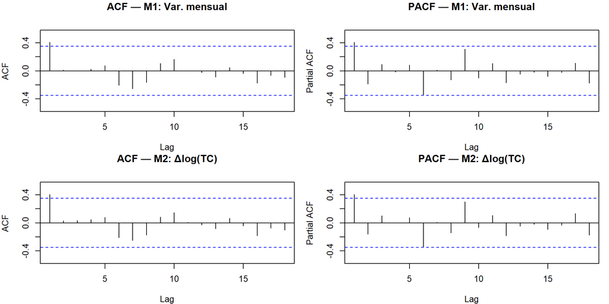

# 3 Estimación y Selección — Dos Métodos

El scoring compuesto integra: **RMSE** + **MAPE** + promedio(**AICc**, **BIC**, **Hannan-Quinn**) + 0.3 × Complejidad + penalizaciones por Ljung-Box y raíces inversas.

## 3.1 M1: Método Directo (variación mensual %)

M1 Directo — Top 15 de 49 modelos (variable: variación mensual %)

| Modelo | d | AICc | BIC | HQ | RMSE | MAPE | LB12(p) | Raices | Score |
| --- | --- | --- | --- | --- | --- | --- | --- | --- | --- |
| ARIMA(2,1,4) | 1 | 210.59 | 215.31 | 208.64 | 4.6687 | 238.208 | 0.2305 | OK | -4.205 |
| ARIMA(2,0,3) | 0 | 213.64 | 218.81 | 212.04 | 4.5705 | 286.948 | 0.4566 | OK | -2.966 |
| ARIMA(1,1,2) | 1 | 210.46 | 214.46 | 210.65 | 6.3523 | 244.709 | 0.1460 | OK | -2.665 |
| ARIMA(4,1,4) | 1 | 218.01 | 221.62 | 213.04 | 4.5112 | 257.246 | 0.1624 | OK | -2.365 |
| ARIMA(2,0,4) | 0 | 216.93 | 221.86 | 214.13 | 4.4489 | 298.831 | 0.4049 | OK | -2.108 |
| ARIMA(2,1,2) | 1 | 213.19 | 217.70 | 212.94 | 6.3403 | 233.339 | 0.1274 | OK | -2.034 |
| ARIMA(0,1,4) | 1 | 213.21 | 217.71 | 212.95 | 6.3189 | 239.742 | 0.1032 | OK | -1.962 |
| ARIMA(3,1,3) | 1 | 215.16 | 219.87 | 213.20 | 5.4596 | 259.892 | 0.0887 | OK | -1.953 |
| ARIMA(1,1,3) | 1 | 213.27 | 217.77 | 213.01 | 6.3489 | 237.410 | 0.1157 | OK | -1.949 |
| ARIMA(0,1,3) | 1 | 210.87 | 214.88 | 211.07 | 6.3763 | 291.566 | 0.0851 | OK | -1.869 |
| ARIMA(3,1,2) | 1 | 216.23 | 220.98 | 215.27 | 6.2980 | 227.653 | 0.0760 | OK | -1.323 |
| ARIMA(1,1,4) | 1 | 216.25 | 221.00 | 215.28 | 6.3231 | 227.786 | 0.0903 | OK | -1.291 |
| ARIMA(2,1,3) | 1 | 216.31 | 221.06 | 215.34 | 6.3224 | 229.985 | 0.0808 | OK | -1.245 |
| ARIMA(4,1,3) | 1 | 217.39 | 221.74 | 214.12 | 5.3060 | 294.056 | 0.1917 | OK | -1.084 |
| ARIMA(3,0,4) | 0 | 220.80 | 225.13 | 216.43 | 4.4863 | 310.993 | 0.2575 | OK | -0.997 |

> M1 elegiría **ARIMA(2,1,4)** por score propio, pero se fuerza a **ARIMA(2,0,3)** (mismo AR/MA que M2, con d=0 porque la variación mensual ya es una primera diferencia del log(TC)).

## 3.2 M2: Método Logarítmico (log TC digital)

M2 Logarítmico — Top 15 de 49 modelos (variable: log TC digital)

| Modelo | d | AICc | BIC | HQ | RMSE | MAPE | LB12(p) | Raices | Score |
| --- | --- | --- | --- | --- | --- | --- | --- | --- | --- |
| ARIMA(2,1,3) | 1 | -69.24 | -64.14 | -69.93 | 0.05471 | 1.584 | 0.6385 | OK | -2.361 |
| ARIMA(1,1,1) | 1 | -72.80 | -69.38 | -72.28 | 0.06390 | 1.869 | 0.6085 | OK | -1.791 |
| ARIMA(3,1,2) | 1 | -67.97 | -62.87 | -68.67 | 0.05722 | 1.635 | 0.3560 | OK | -1.761 |
| ARIMA(2,1,4) | 1 | -66.02 | -60.85 | -67.62 | 0.05453 | 1.577 | 0.5635 | OK | -1.743 |
| ARIMA(2,1,1) | 1 | -70.77 | -66.58 | -70.44 | 0.06262 | 1.779 | 0.5715 | OK | -1.621 |
| ARIMA(3,0,3) | 0 | -64.28 | -58.82 | -66.65 | 0.05425 | 1.569 | 0.2123 | OK | -1.526 |
| ARIMA(1,1,2) | 1 | -70.57 | -66.37 | -70.24 | 0.06280 | 1.798 | 0.5737 | OK | -1.519 |
| ARIMA(0,1,2) | 1 | -71.95 | -68.53 | -71.43 | 0.06520 | 1.931 | 0.3690 | OK | -1.357 |
| ARIMA(0,1,1) | 1 | -72.64 | -70.20 | -72.14 | 0.06823 | 1.953 | 0.4343 | OK | -1.322 |
| ARIMA(0,1,3) | 1 | -70.43 | -66.23 | -70.10 | 0.06368 | 1.866 | 0.4350 | OK | -1.232 |
| ARIMA(4,0,2) | 0 | -63.88 | -58.41 | -66.25 | 0.05578 | 1.614 | 0.0926 | OK | -1.188 |
| ARIMA(3,0,2) | 0 | -66.27 | -60.68 | -67.54 | 0.05823 | 1.727 | 0.0533 | OK | -1.140 |
| ARIMA(1,1,3) | 1 | -68.02 | -63.25 | -68.08 | 0.06248 | 1.761 | 0.4866 | OK | -1.050 |
| ARIMA(2,0,1) | 0 | -69.11 | -64.09 | -68.99 | 0.06353 | 1.846 | 0.2478 | OK | -1.041 |
| ARIMA(3,0,1) | 0 | -67.20 | -61.76 | -67.64 | 0.06162 | 1.742 | 0.2220 | OK | -1.032 |

## 3.3 Comparación (M1: ARIMA(2,0,3) vs M2: ARIMA(2,1,3))

M1: ARIMA(2,0,3) sobre var. mensual vs M2: ARIMA(2,1,3) sobre log(TC)

| Criterio | M1: Directo | M2: Logarítmico |
| --- | --- | --- |
| Especificación forzada | ARIMA(2,0,3) | ARIMA(2,1,3) |
| AIC | 208.77 | -72.74 |
| BIC | 218.81 | -64.14 |
| AICc | 213.64 | -69.24 |
| Hannan-Quinn | 212.04 | -69.93 |
| RMSE (train) | 4.570489 | 0.054708 |
| MAPE (train) | 286.9481 | 1.5838 |
| Ljung-Box h=12 (p) | 0.4566 | 0.6385 |

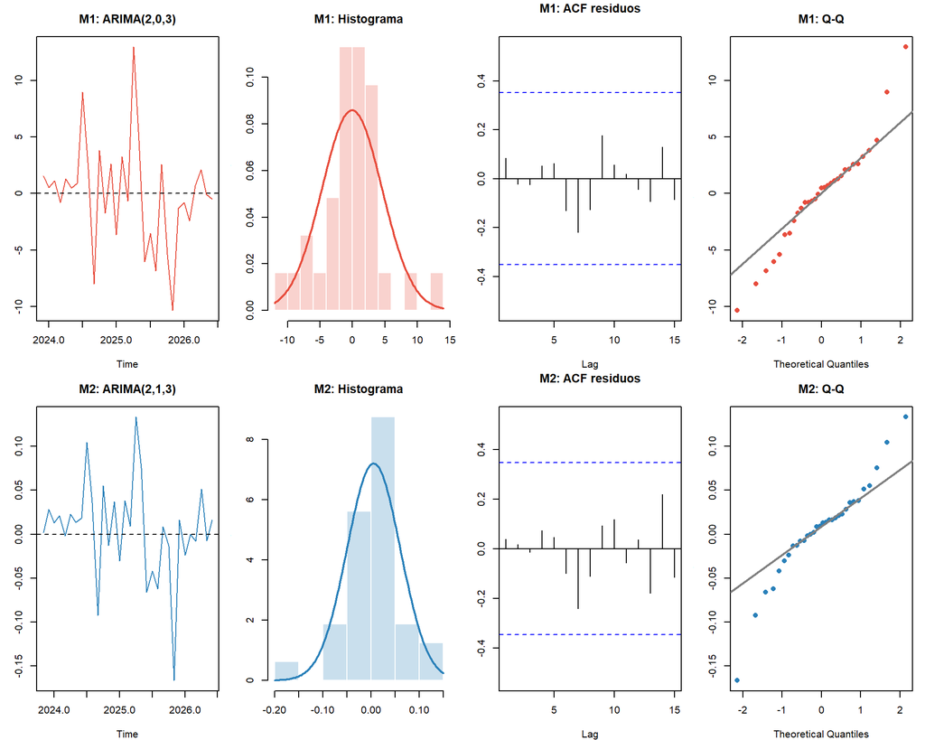

# 4 Backtesting

Se reservan los últimos 6 meses. M1 usa **ARIMA(2,0,3)** y M2 usa **ARIMA(2,1,3)**. Se comparan en **TC digital (niveles)**.

Backtesting — TC digital observado vs. pronosticado

| Fecha | Obs. (Bs/USD) | M1 pron. | M1 error | M2 pron. | M2 error |
| --- | --- | --- | --- | --- | --- |
| ene 2026 | 9.4736 | 10.2515 | 0.7779 | 10.4317 | 0.9581 |
| feb 2026 | 9.0775 | 10.7249 | 1.6474 | 10.4005 | 1.3230 |
| mar 2026 | 9.2585 | 11.2624 | 2.0039 | 10.2761 | 1.0176 |
| abr 2026 | 9.4446 | 11.7350 | 2.2904 | 10.2073 | 0.7627 |
| may 2026 | 10.0009 | 12.1944 | 2.1936 | 10.2317 | 0.2309 |
| jun 2026 | 9.9393 | 12.6271 | 2.6878 | 10.2898 | 0.3505 |

Métricas de backtesting

| Métrica | M1: Directo | M2: Logarítmico |
| --- | --- | --- |
| RMSE (Bs/USD) | 2.0255 | 0.8623 |
| MAPE (%) | 20.21% | 8.26% |

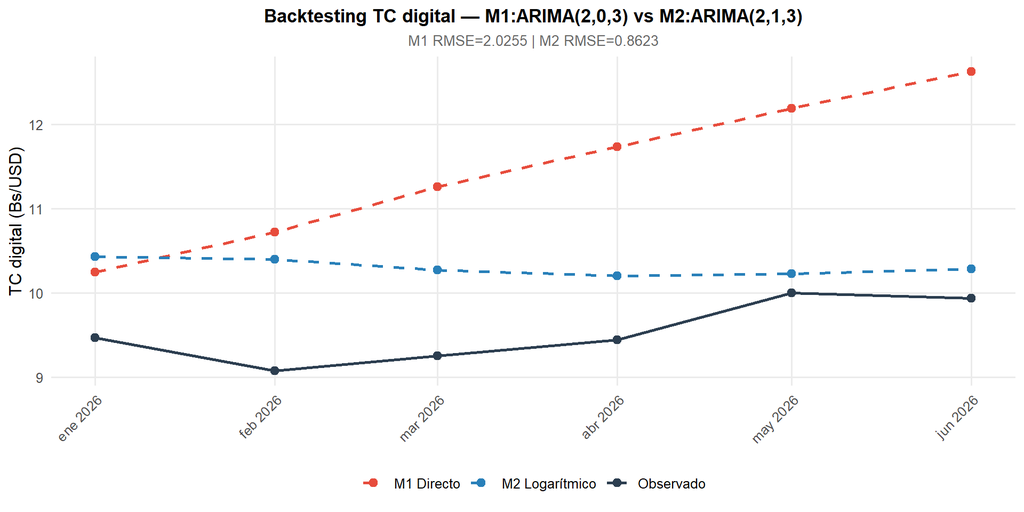

# 5 Pronóstico Final

## 5.1 Proyección comparada — TC digital

Proyección de TC digital — M1: ARIMA(2,0,3) vs M2: ARIMA(2,1,3)

| Mes | M1 TC digital | M2 TC digital | M1 var. mensual (%) | M2 var. mensual (%) |
| --- | --- | --- | --- | --- |
| Julio | 10.0616 | 10.1268 | 1.230 | 1.886 |
| Agosto | 10.2781 | 10.1827 | 2.152 | 0.553 |
| Septiembre | 10.2730 | 10.0240 | -0.050 | -1.559 |
| Octubre | 10.6158 | 10.2500 | 3.337 | 2.255 |
| Noviembre | 10.5689 | 10.0037 | -0.441 | -2.403 |
| Diciembre | 10.8789 | 10.2237 | 2.933 | 2.199 |
| Enero | 10.9442 | 10.0674 | 0.600 | -1.528 |

## 5.2 Fan chart — M2 (log-normal) con referencia M1

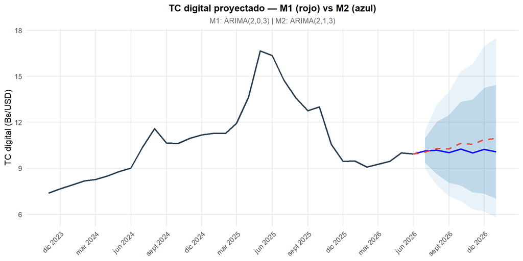

*Scoring compuesto: RMSE + MAPE + (AICc + BIC + HQ)/3 + 0.3·Complejidad + penalizaciones LB y raíces.* *M1: ARIMA(2,0,3) sobre var. mensual (d=0) | M2: ARIMA(2,1,3) sobre log(TC) (d=1). Mismo AR/MA, diferenciación equivalente.* *Muestra: nov 2023–jun 2026 (n=32) — sin regresores exógenos; ver ARIMAX_TC.Rmd para el modelo con inflación interanual como predictor.*